# Final Project — Building Energy Load: Integrated Analysis

Group 5

2026-06-12

# 1 Overview

This document integrates all stages of the ENB2012 building energy analysis into a single reproducible workflow. The sections follow a deliberate progression:

1. **EDA** — characterise the data structure, identify multicollinearity, and establish the physical signals that every subsequent model will need to respect.
2. **Linear Regression** — establish a regularised linear baseline using Ridge, Lasso, and Elastic Net, motivated directly by the VIF findings from the EDA.
3. **Domain-Appropriate Regression** — apply Gaussian Process Regression and LightGBM, which are specifically suited to simulation-generated tabular data; compare against the linear baseline from the previous section.
4. **Domain-Appropriate Classification** — reframe the prediction problem as ordinal energy class assignment, using models that respect the Low/Medium/High ordering and a regulatory domain baseline for comparison.
5. **Cross-Model Comparison and Conclusions** — synthesise regression and classification results, identify which models to carry forward, and contextualise the findings in terms of physical interpretability.

The same 80/20 group-aware train/test split (seed = 42) and the same 16 engineered features are used throughout. All scalers are fitted on training data only.

# 2 Packages

```r
pkgs <- c(
  # Core
  "tidyverse", "readxl", "writexl",
  # EDA
  "corrplot", "ggcorrplot", "ggridges", "psych", "nortest",
  "car", "gridExtra",
  # Regression
  "caret", "glmnet", "broom", "lmtest",
  # Domain-appropriate regression
  "kernlab",   # GPR
  "lightgbm",  # LightGBM
  # Classification
  "ranger",       # probability forest (used in place of ordinalForest)
  "naivebayes",   # Gaussian Naive Bayes
  "pROC",         # Multiclass AUC
  "knitr",
  # Nonlinear
   "earth",  # MARS
   "e1071",  # SVR
   "grf"
)
lapply(pkgs, library, character.only = TRUE)
```

[output not shown]

[output cut: 178 more lines]

```r
img_dir <- "~/Documents/strathmore/Modules/Module 3/linear_models/classwork/final_project/markdowns/integrated_analysis_files/images"
dir.create(img_dir, showWarnings = FALSE, recursive = TRUE)
```

# 3 Part 1 — Exploratory Data Analysis

## 3.1 Data Loading and Variable Definitions

```r
df <- read_excel(
  "~/Documents/strathmore/Modules/Module 3/linear_models/classwork/final_project/data/ENB2012_data 2.xlsx"
)

colnames(df) <- c(
  "RelCompactness", "SurfaceArea", "WallArea", "RoofArea",
  "OverallHeight", "Orientation", "GlazingArea",
  "GlazingAreaDist", "HeatingLoad", "CoolingLoad"
)

cat("Dimensions:", nrow(df), "rows x", ncol(df), "columns\n")
```

```
## Dimensions: 768 rows x 10 columns
```

## 3.2 Dataset Structure and the Combinatorial Grid

ENB2012 was generated by the EnergyPlus simulator by systematically varying eight building parameters across fixed discrete levels. This gives the dataset a combinatorial grid structure where every combination of parameter values appears exactly four times — once per compass orientation. The critical consequence for modelling is that a naive random train/test split will leak building configurations between sets, since orientation variants of the same building will appear on both sides. All downstream modelling accounts for this through a group-aware split.

```r
cat("Unique values per variable:\n")
```

```
## Unique values per variable:
```

```r
sapply(df, function(x) length(unique(x)))
```

```
##  RelCompactness     SurfaceArea        WallArea        RoofArea   OverallHeight
##              12              12               7               4               2
##     Orientation     GlazingArea GlazingAreaDist     HeatingLoad     CoolingLoad
##               4               4               6             587             636
```

```r
# Group key: uniquely identifies each building configuration (excluding orientation)
df <- df %>%
  mutate(group_key = paste(RelCompactness, WallArea, RoofArea,
                           OverallHeight, GlazingArea, GlazingAreaDist,
                           sep = "_"))

cat("\nTotal rows:", nrow(df), "\n")
```

```
##
## Total rows: 768
```

```r
cat("Unique building configurations:", length(unique(df$group_key)), "\n")
```

```
## Unique building configurations: 192
```

```r
cat("Rows per configuration (should be 4):\n")
```

```
## Rows per configuration (should be 4):
```

```r
print(table(table(df$group_key)))
```

```
##
##   4
## 192
```

## 3.3 Missing Values, Duplicates, and Data Quality

```r
cat("Missing values per column:\n")
```

```
## Missing values per column:
```

```r
print(colSums(is.na(df)))
```

```
##  RelCompactness     SurfaceArea        WallArea        RoofArea   OverallHeight
##               0               0               0               0               0
##     Orientation     GlazingArea GlazingAreaDist     HeatingLoad     CoolingLoad
##               0               0               0               0               0
##       group_key
##               0
```

```r
cat("\nDuplicated rows:", sum(duplicated(df)), "\n")
```

```
##
## Duplicated rows: 0
```

ENB2012 has no missing values by construction. Any duplicated rows would indicate a simulation export error. No duplicates are present.

## 3.4 Univariate Distributions

### 3.4.1 Continuous variables

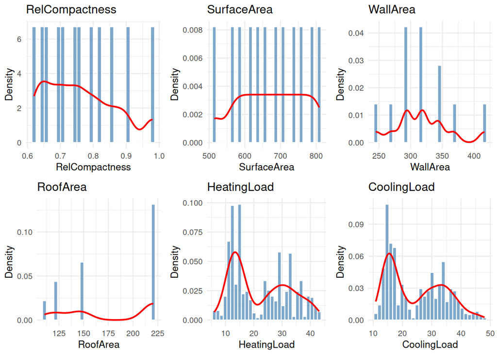

```r
cont_vars <- c("RelCompactness", "SurfaceArea", "WallArea",
               "RoofArea", "HeatingLoad", "CoolingLoad")

p_hist <- lapply(cont_vars, function(v) {
  ggplot(df, aes(x = .data[[v]])) +
    geom_histogram(aes(y = after_stat(density)), bins = 30,
                   fill = "steelblue", color = "white", alpha = 0.7) +
    geom_density(color = "red", linewidth = 0.8) +
    labs(title = v, x = v, y = "Density") +
    theme_minimal(base_size = 10)
})
do.call(grid.arrange, c(p_hist, ncol = 3))
```

`RelCompactness` is roughly uniform, reflecting the systematic grid design. `HeatingLoad` and `CoolingLoad` are both bimodal, with modes corresponding to the two levels of `OverallHeight`. This bimodality is structural, not noise, and motivates treating `OverallHeight` as a key stratifying variable throughout the analysis.

### 3.4.2 Discrete and categorical variables

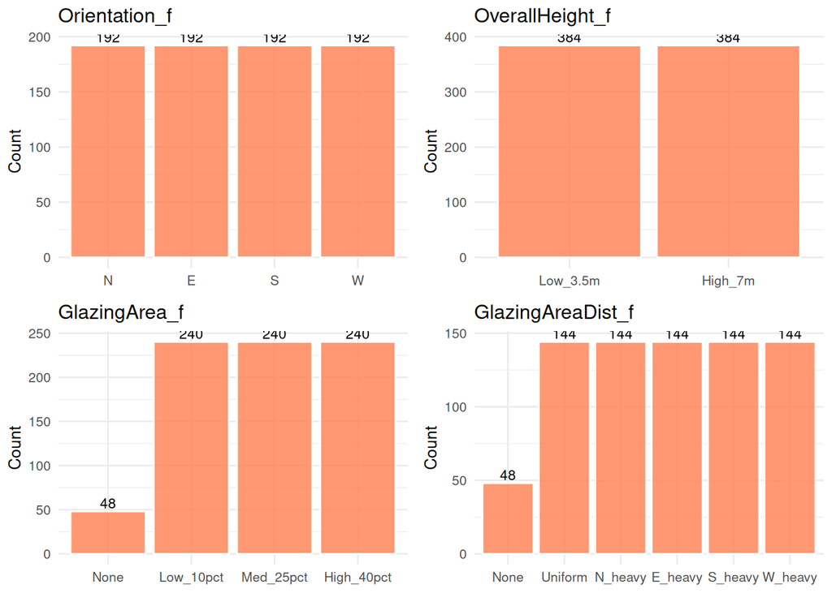

```r
df$Orientation_f     <- factor(df$Orientation,     levels = 2:5,
                                labels = c("N", "E", "S", "W"))
df$OverallHeight_f   <- factor(df$OverallHeight,   levels = c(3.5, 7.0),
                                labels = c("Low_3.5m", "High_7m"))
df$GlazingArea_f     <- factor(df$GlazingArea,     levels = c(0, 0.1, 0.25, 0.4),
                                labels = c("None","Low_10pct","Med_25pct","High_40pct"))
df$GlazingAreaDist_f <- factor(df$GlazingAreaDist, levels = 0:5,
                                labels = c("None","Uniform","N_heavy",
                                           "E_heavy","S_heavy","W_heavy"))

cat_vars <- c("Orientation_f", "OverallHeight_f", "GlazingArea_f", "GlazingAreaDist_f")

p_bar <- lapply(cat_vars, function(v) {
  ggplot(df, aes(x = .data[[v]])) +
    geom_bar(fill = "coral", color = "white", alpha = 0.8) +
    geom_text(stat = "count", aes(label = after_stat(count)), vjust = -0.3, size = 3) +
    labs(title = v, x = NULL, y = "Count") +
    theme_minimal(base_size = 10)
})
do.call(grid.arrange, c(p_bar, ncol = 2))
```

All four orientation values appear with equal frequency (192 buildings each), confirming the balanced grid design. `GlazingAreaDist` level 0 (no distribution) corresponds exactly to buildings with zero `GlazingArea`, creating a structural dependency between these two variables.

## 3.5 Response Variable Analysis

### 3.5.1 Normality assessment

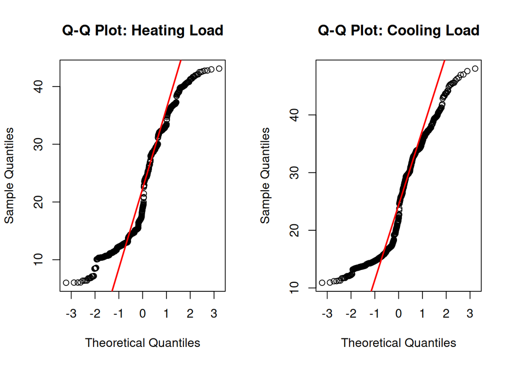

```r
par(mfrow = c(1, 2))
qqnorm(df$HeatingLoad, main = "Q-Q Plot: Heating Load")
qqline(df$HeatingLoad, col = "red", lwd = 2)
qqnorm(df$CoolingLoad, main = "Q-Q Plot: Cooling Load")
qqline(df$CoolingLoad, col = "red", lwd = 2)
```

```r
par(mfrow = c(1, 1))

cat("Anderson-Darling test — Heating Load:\n")
```

```
## Anderson-Darling test — Heating Load:
```

```r
print(nortest::ad.test(df$HeatingLoad))
```

```
##
##  Anderson-Darling normality test
##
## data:  df$HeatingLoad
## A = 26.863, p-value < 2.2e-16
```

```r
cat("\nAnderson-Darling test — Cooling Load:\n")
```

```
##
## Anderson-Darling test — Cooling Load:
```

```r
print(nortest::ad.test(df$CoolingLoad))
```

```
##
##  Anderson-Darling normality test
##
## data:  df$CoolingLoad
## A = 27.122, p-value < 2.2e-16
```

Both responses deviate significantly from normality (AD p < 2.2e-16 for both), consistent with their bimodal distributions. This does not invalidate linear regression but means residual diagnostics will matter. It directly motivates exploring nonlinear models and classification approaches alongside the linear models in later sections.

### 3.5.2 Distribution by Overall Height

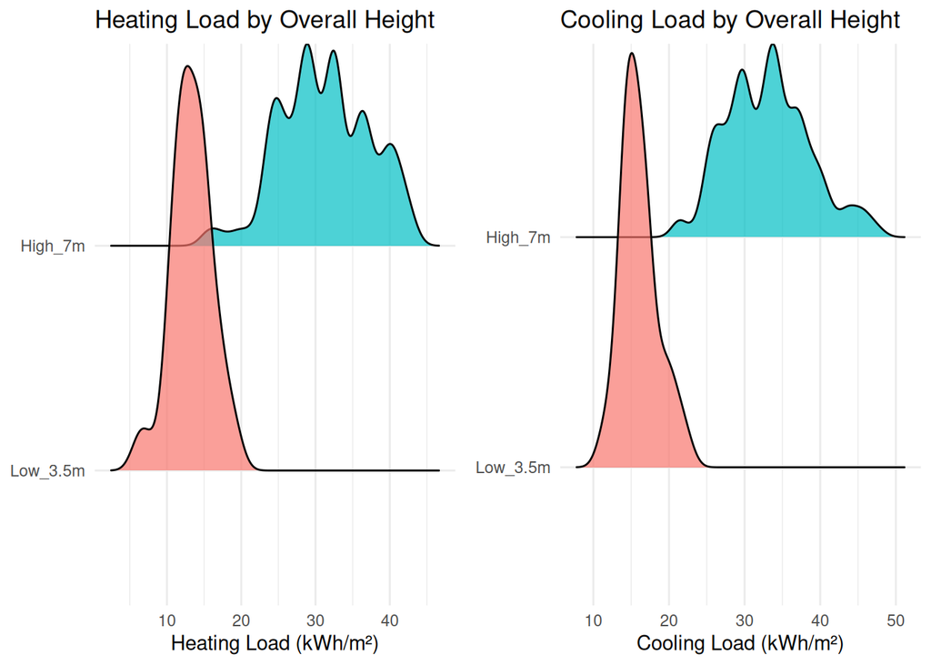

```r
p_rl1 <- ggplot(df, aes(x = HeatingLoad, y = OverallHeight_f,
                         fill = OverallHeight_f)) +
  geom_density_ridges(alpha = 0.7) +
  labs(title = "Heating Load by Overall Height",
       x = "Heating Load (kWh/m²)", y = NULL) +
  theme_minimal() + theme(legend.position = "none")

p_rl2 <- ggplot(df, aes(x = CoolingLoad, y = OverallHeight_f,
                         fill = OverallHeight_f)) +
  geom_density_ridges(alpha = 0.7) +
  labs(title = "Cooling Load by Overall Height",
       x = "Cooling Load (kWh/m²)", y = NULL) +
  theme_minimal() + theme(legend.position = "none")

grid.arrange(p_rl1, p_rl2, ncol = 2)
```

## 3.6 Feature-Response Relationships

### 3.6.1 Scatter plots with LOESS smooths

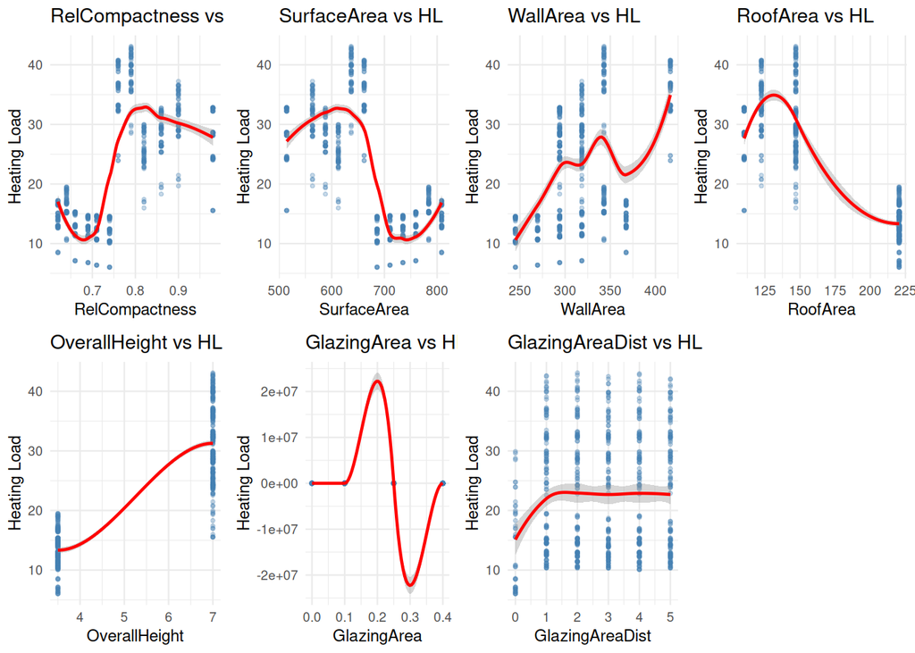

```r
feature_vars <- c("RelCompactness", "SurfaceArea", "WallArea", "RoofArea",
                  "OverallHeight", "GlazingArea", "GlazingAreaDist")

p_y1 <- lapply(feature_vars, function(v) {
  ggplot(df, aes(x = .data[[v]], y = HeatingLoad)) +
    geom_point(alpha = 0.3, color = "steelblue", size = 0.8) +
    geom_smooth(method = "loess", color = "red", se = TRUE, linewidth = 0.8) +
    labs(title = paste(v, "vs HL"), x = v, y = "Heating Load") +
    theme_minimal(base_size = 9)
})
do.call(grid.arrange, c(p_y1, ncol = 4))
```

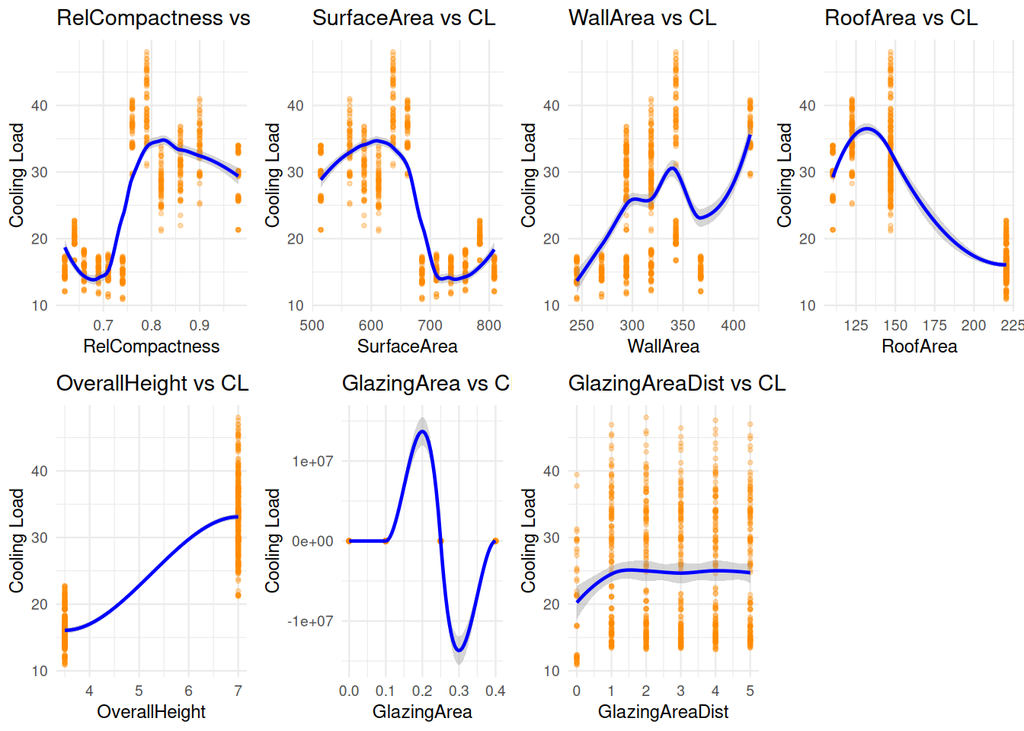

```r
p_y2 <- lapply(feature_vars, function(v) {
  ggplot(df, aes(x = .data[[v]], y = CoolingLoad)) +
    geom_point(alpha = 0.3, color = "darkorange", size = 0.8) +
    geom_smooth(method = "loess", color = "blue", se = TRUE, linewidth = 0.8) +
    labs(title = paste(v, "vs CL"), x = v, y = "Cooling Load") +
    theme_minimal(base_size = 9)
})
do.call(grid.arrange, c(p_y2, ncol = 4))
```

### 3.6.2 Interaction: OverallHeight × GlazingArea

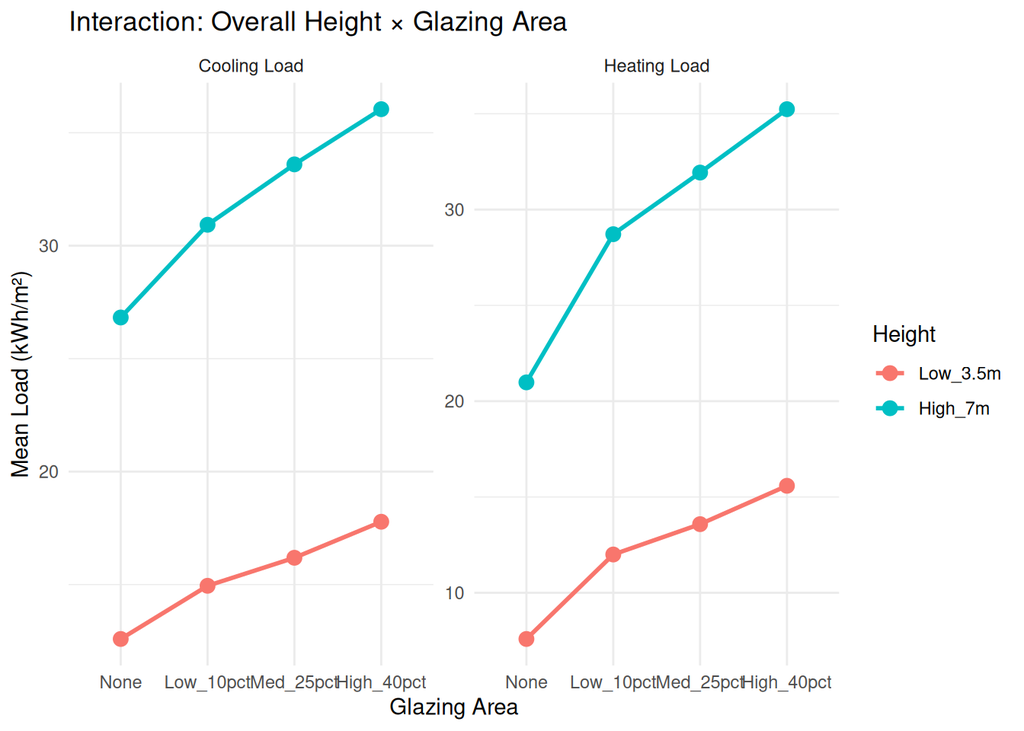

```r
df %>%
  group_by(OverallHeight_f, GlazingArea_f) %>%
  summarise(mean_HL = mean(HeatingLoad),
            mean_CL = mean(CoolingLoad), .groups = "drop") %>%
  pivot_longer(c(mean_HL, mean_CL),
               names_to = "Response", values_to = "Mean") %>%
  mutate(Response = case_when(
    Response == "mean_HL" ~ "Heating Load",
    Response == "mean_CL" ~ "Cooling Load"
  )) %>%
  ggplot(aes(x = GlazingArea_f, y = Mean,
             color = OverallHeight_f, group = OverallHeight_f)) +
  geom_line(linewidth = 1) +
  geom_point(size = 3) +
  facet_wrap(~ Response, scales = "free_y") +
  labs(title    = "Interaction: Overall Height × Glazing Area",
       x = "Glazing Area", y = "Mean Load (kWh/m²)", color = "Height") +
  theme_minimal()
```

## 3.7 Correlation and Multicollinearity

### 3.7.1 Correlation heatmap

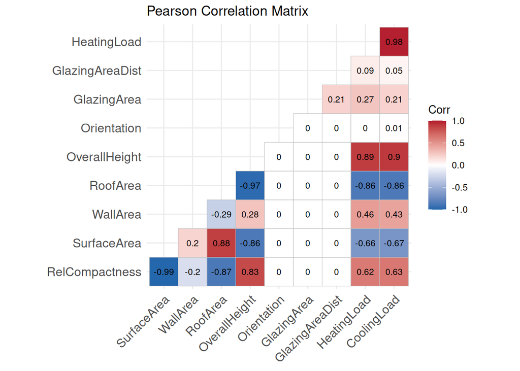

```r
cor_matrix <- cor(df %>% dplyr::select(RelCompactness:CoolingLoad),
                  method = "pearson")

ggcorrplot(cor_matrix, type = "lower", lab = TRUE, lab_size = 3,
           colors = c("#2166AC", "white", "#B2182B"),
           title  = "Pearson Correlation Matrix",
           ggtheme = theme_minimal())
```

`SurfaceArea` is almost perfectly negatively correlated with `RelCompactness` (r ≈ −0.99) — a mathematical near-identity because relative compactness is defined as the volume-to-surface-area ratio. Including both causes exact or near-exact multicollinearity and `SurfaceArea` is excluded from all models. `HeatingLoad` and `CoolingLoad` are highly correlated (r ≈ 0.98), reflecting that the same physical factors drive both; they are modelled separately throughout.

### 3.7.2 VIF analysis

```r
prelim_model <- lm(HeatingLoad ~ RelCompactness + WallArea + RoofArea +
                     OverallHeight + Orientation + GlazingArea +
                     GlazingAreaDist, data = df)

cat("VIF — SurfaceArea excluded to resolve perfect collinearity:\n")
```

```
## VIF — SurfaceArea excluded to resolve perfect collinearity:
```

```r
print(car::vif(prelim_model))
```

```
##  RelCompactness        WallArea        RoofArea   OverallHeight     Orientation
##      105.524054       27.662740      211.938336       31.205474        1.000000
##     GlazingArea GlazingAreaDist
##        1.047508        1.047508
```

The VIF results establish the severity of the collinearity problem. `RoofArea` (VIF=211.9) and `RelCompactness` (VIF=105.5) are almost entirely explained by linear combinations of the other predictors. `WallArea` (27.7) and `OverallHeight` (31.2) also breach the threshold of 10 by a wide margin. Only `Orientation`, `GlazingArea`, and `GlazingAreaDist` are clean. This directly motivates the choice of regularised regression in Part 2 — Ridge and Elastic Net are designed to handle correlated predictors by shrinking coefficients rather than relying on matrix inversion stability.

## 3.8 Outlier Assessment

```r
detect_outliers <- function(x) {
  q1  <- quantile(x, 0.25)
  q3  <- quantile(x, 0.75)
  iqr <- q3 - q1
  sum(x < (q1 - 1.5 * iqr) | x > (q3 + 1.5 * iqr))
}

cat("IQR-based outlier counts:\n")
```

```
## IQR-based outlier counts:
```

```r
print(sapply(df %>% dplyr::select(RelCompactness:CoolingLoad),
             detect_outliers))
```

```
##  RelCompactness     SurfaceArea        WallArea        RoofArea   OverallHeight
##               0               0               0               0               0
##     Orientation     GlazingArea GlazingAreaDist     HeatingLoad     CoolingLoad
##               0               0               0               0               0
```

## 3.9 Export Post-EDA Dataset

```r
write_xlsx(df, "ENB2012_post_EDA.xlsx")
cat("Exported: ENB2012_post_EDA.xlsx\n")
```

```
## Exported: ENB2012_post_EDA.xlsx
```

```r
cat("Dimensions:", nrow(df), "rows x", ncol(df), "columns\n")
```

```
## Dimensions: 768 rows x 15 columns
```

# 4 Part 2 — Linear Regression Models

```r
df <- df %>%
  mutate(group_key = paste(RelCompactness, WallArea, RoofArea,
                           OverallHeight, GlazingArea, GlazingAreaDist, sep = "_"))

set.seed(42)
unique_groups  <- unique(df$group_key)
n_train_groups <- round(0.80 * length(unique_groups))
train_groups   <- sample(unique_groups, n_train_groups)

df_train <- df %>% filter( group_key %in% train_groups)
df_test  <- df %>% filter(!group_key %in% train_groups)

cat("Training rows:", nrow(df_train), "\n")
```

```
## Training rows: 616
```

```r
cat("Test rows    :", nrow(df_test),  "\n")
```

```
## Test rows    : 152
```

```r
cat("Group overlap:", length(intersect(df_train$group_key, df_test$group_key)),
    "<- zero confirms no leakage\n")
```

```
## Group overlap: 0 <- zero confirms no leakage
```

## 4.1 Feature Engineering

The EDA interaction plot showed that the effect of glazing area on heating load is steeper for tall buildings, confirming a genuine `OverallHeight × GlazingArea` interaction. The VIF analysis showed severe collinearity among the geometric variables, which motivates constructing physically interpretable composite features that capture cross-variable relationships while reducing redundancy.

```r
engineer <- function(d) {
  d %>% mutate(
    CompactnessXHeight  = RelCompactness * OverallHeight,
    WallToRoofRatio     = WallArea / RoofArea,
    GlazingXCompactness = GlazingArea * RelCompactness,
    SurfToVol           = SurfaceArea / (WallArea + RoofArea),
    GlazingXHeight      = GlazingArea * OverallHeight,
    WallXGlazing        = WallArea * GlazingArea,
    CompactnessSquared  = RelCompactness^2,
    HeightSquared       = OverallHeight^2,
    GlazingToWall       = GlazingArea / (WallArea + 1),
    EnvelopeArea        = WallArea + RoofArea,
    WallPerHeight       = WallArea / (OverallHeight + 1)
  )
}

df_train <- engineer(df_train)
df_test  <- engineer(df_test)

cat("Engineered feature count:", ncol(df_train), "\n")
```

```
## Engineered feature count: 26
```

`SurfaceArea` is excluded from all models: the EDA confirmed it is a near-perfect linear combination of `WallArea` and `RoofArea` (r ≈ −0.99 with `RelCompactness`), causing rank deficiency in the model matrix.

## 4.2 Scaling

```r
base_features <- c(
  "RelCompactness", "WallArea", "RoofArea", "OverallHeight",
  "GlazingArea", "GlazingAreaDist",
  "CompactnessXHeight", "WallToRoofRatio", "GlazingXCompactness",
  "SurfToVol", "GlazingXHeight", "WallXGlazing",
  "CompactnessSquared", "GlazingToWall", "EnvelopeArea", "WallPerHeight"
)

preproc_reg <- caret::preProcess(df_train[, base_features],
                                  method = c("center", "scale"))
df_train[, base_features] <- predict(preproc_reg, df_train[, base_features])
df_test[, base_features]  <- predict(preproc_reg, df_test[, base_features])

cat("Scaling complete. Fitted on training set only.\n")
```

```
## Scaling complete. Fitted on training set only.
```

## 4.3 Evaluation Helper

```r
eval_reg <- function(actual, predicted, model_name) {
  residuals <- actual - predicted
  rmse <- sqrt(mean(residuals^2))
  mae  <- mean(abs(residuals))
  r2   <- 1 - sum(residuals^2) / sum((actual - mean(actual))^2)
  cat(sprintf("%-40s  RMSE = %6.3f  MAE = %6.3f  R² = %.4f\n",
              model_name, rmse, mae, r2))
  list(model_name = model_name, rmse = rmse, mae = mae, r2 = r2)
}

results_HL <- data.frame()
results_CL <- data.frame()
```

## 4.4 Model 1 — Baseline OLS

The first model uses only the original features (minus `SurfaceArea`) with no engineering. This establishes a performance floor against which all subsequent models are compared.

```r
formula_base <- HeatingLoad ~ RelCompactness + WallArea + RoofArea +
                              OverallHeight + GlazingArea + GlazingAreaDist +
                              Orientation

lm_base_HL <- lm(formula_base, data = df_train)
cat("=== BASELINE OLS — Heating Load ===\n")
```

```
## === BASELINE OLS — Heating Load ===
```

```r
print(summary(lm_base_HL))
```

```
##
## Call:
## lm(formula = formula_base, data = df_train)
##
## Residuals:
##      Min       1Q   Median       3Q      Max
## -10.2361  -1.3102  -0.0322   1.4210   7.2835
##
## Coefficients:
##                 Estimate Std. Error t value Pr(>|t|)
## (Intercept)     23.00327    0.39304  58.526  < 2e-16 ***
## RelCompactness  -7.16454    1.21087  -5.917 5.48e-09 ***
## WallArea        -1.23845    0.63203  -1.959  0.05051 .
## RoofArea        -7.36705    1.70217  -4.328 1.76e-05 ***
## OverallHeight    8.12526    0.65661  12.374  < 2e-16 ***
## GlazingArea      2.56497    0.12366  20.742  < 2e-16 ***
## GlazingAreaDist  0.36158    0.12325   2.934  0.00347 **
## Orientation     -0.02256    0.10697  -0.211  0.83305
## ---
## Signif. codes:  0 '***' 0.001 '**' 0.01 '*' 0.05 '.' 0.1 ' ' 1
##
## Residual standard error: 2.968 on 608 degrees of freedom
## Multiple R-squared:  0.9132, Adjusted R-squared:  0.9122
## F-statistic: 913.2 on 7 and 608 DF,  p-value: < 2.2e-16
```

```r
pred_base_HL <- predict(lm_base_HL, newdata = df_test)
res_base_HL  <- eval_reg(df_test$HeatingLoad, pred_base_HL, "Baseline OLS")
```

```
## Baseline OLS                              RMSE =  2.840  MAE =  2.158  R² = 0.9195
```

```r
results_HL <- rbind(results_HL,
  data.frame(Model = "Baseline OLS",
             RMSE = res_base_HL$rmse, MAE = res_base_HL$mae, R2 = res_base_HL$r2))
```

For the Cooling Load, we have

```r
y_train_CL <- df_train$CoolingLoad
y_test_CL  <- df_test$CoolingLoad

# Baseline OLS
formula_base_CL <- CoolingLoad ~ RelCompactness + WallArea + RoofArea +
                                  OverallHeight + GlazingArea +
                                  GlazingAreaDist + Orientation
lm_base_CL <- lm(formula_base_CL, data = df_train)
pred_base_CL <- predict(lm_base_CL, newdata = df_test)
res_base_CL  <- eval_reg(y_test_CL, pred_base_CL, "Baseline OLS")
```

```
## Baseline OLS                              RMSE =  3.161  MAE =  2.306  R² = 0.8832
```

```r
results_CL   <- rbind(results_CL,
  data.frame(Model = "Baseline OLS",
             RMSE = res_base_CL$rmse, MAE = res_base_CL$mae, R2 = res_base_CL$r2))
```

The baseline achieves R²=0.919 and RMSE=2.840 kWh/m². Despite the severe VIFs documented in the EDA, the overall fit is reasonable because R² aggregates all predictors — collinearity inflates individual standard errors but does not prevent the combined signal from being captured. Orientation (p=0.833) is already near-zero, consistent with its flat LOESS curve in the EDA. This RMSE of 2.840 is the performance floor all subsequent models are measured against.

## 4.5 Model 2 — OLS with Interaction Terms

```r
formula_interact <- HeatingLoad ~ RelCompactness + WallArea + RoofArea +
                                  OverallHeight + GlazingArea + GlazingAreaDist +
                                  Orientation +
                                  CompactnessXHeight + GlazingXHeight +
                                  WallXGlazing + GlazingXCompactness

lm_interact_HL <- lm(formula_interact, data = df_train)
cat("=== OLS WITH INTERACTIONS — Heating Load ===\n")
```

```
## === OLS WITH INTERACTIONS — Heating Load ===
```

```r
print(summary(lm_interact_HL))
```

```
##
## Call:
## lm(formula = formula_interact, data = df_train)
##
## Residuals:
##     Min      1Q  Median      3Q     Max
## -9.2421 -1.2271 -0.1815  1.2570  6.9280
##
## Coefficients:
##                      Estimate Std. Error t value Pr(>|t|)
## (Intercept)          23.00327    0.36296  63.377  < 2e-16 ***
## RelCompactness       38.60367    7.02902   5.492 5.86e-08 ***
## WallArea             11.66214    2.15961   5.400 9.59e-08 ***
## RoofArea             24.16396    4.85103   4.981 8.26e-07 ***
## OverallHeight        55.32905    6.82244   8.110 2.83e-15 ***
## GlazingArea          -9.33117    2.74242  -3.403 0.000712 ***
## GlazingAreaDist       0.29042    0.11410   2.545 0.011167 *
## Orientation          -0.02256    0.09878  -0.228 0.819443
## CompactnessXHeight  -60.50729    8.74644  -6.918 1.17e-11 ***
## GlazingXHeight       -1.20200    1.22260  -0.983 0.325926
## WallXGlazing          4.92589    1.49782   3.289 0.001065 **
## GlazingXCompactness   8.33588    2.46019   3.388 0.000749 ***
## ---
## Signif. codes:  0 '***' 0.001 '**' 0.01 '*' 0.05 '.' 0.1 ' ' 1
##
## Residual standard error: 2.741 on 604 degrees of freedom
## Multiple R-squared:  0.9264, Adjusted R-squared:  0.9251
## F-statistic: 691.4 on 11 and 604 DF,  p-value: < 2.2e-16
```

```r
pred_interact_HL <- predict(lm_interact_HL, newdata = df_test)
res_interact_HL  <- eval_reg(df_test$HeatingLoad, pred_interact_HL,
                              "OLS with Interactions")
```

```
## OLS with Interactions                     RMSE =  2.470  MAE =  1.768  R² = 0.9391
```

```r
results_HL <- rbind(results_HL,
  data.frame(Model = "OLS with Interactions",
             RMSE = res_interact_HL$rmse, MAE = res_interact_HL$mae,
             R2   = res_interact_HL$r2))
```

For Cooling Load, we have

```r
# OLS with interactions
formula_interact_CL <- CoolingLoad ~ RelCompactness + WallArea + RoofArea +
                                      OverallHeight + GlazingArea +
                                      GlazingAreaDist + Orientation +
                                      CompactnessXHeight + GlazingXHeight +
                                      WallXGlazing + GlazingXCompactness
lm_interact_CL <- lm(formula_interact_CL, data = df_train)
pred_interact_CL <- predict(lm_interact_CL, newdata = df_test)
res_interact_CL  <- eval_reg(y_test_CL, pred_interact_CL, "OLS with Interactions")
```

```
## OLS with Interactions                     RMSE =  2.978  MAE =  2.057  R² = 0.8964
```

```r
results_CL <- rbind(results_CL,
  data.frame(Model = "OLS with Interactions",
             RMSE = res_interact_CL$rmse, MAE = res_interact_CL$mae,
             R2   = res_interact_CL$r2))
```

## 4.6 Model 3 — Ridge Regression

The severe VIFs established in the EDA (up to 212 for `RoofArea`) make Ridge regression a natural choice. Ridge shrinks all coefficients toward zero in proportion to their collinearity, producing stable estimates where OLS cannot.

```r
X_train <- as.matrix(df_train[, base_features])
X_test  <- as.matrix(df_test[,  base_features])
y_train_HL <- df_train$HeatingLoad
y_test_HL  <- df_test$HeatingLoad

set.seed(42)
ridge_cv_HL <- cv.glmnet(X_train, y_train_HL, alpha = 0, nfolds = 10)
cat("=== RIDGE REGRESSION — Heating Load ===\n")
```

```
## === RIDGE REGRESSION — Heating Load ===
```

```r
cat(sprintf("Optimal lambda (1se): %.4f\n", ridge_cv_HL$lambda.1se))
```

```
## Optimal lambda (1se): 1.6941
```

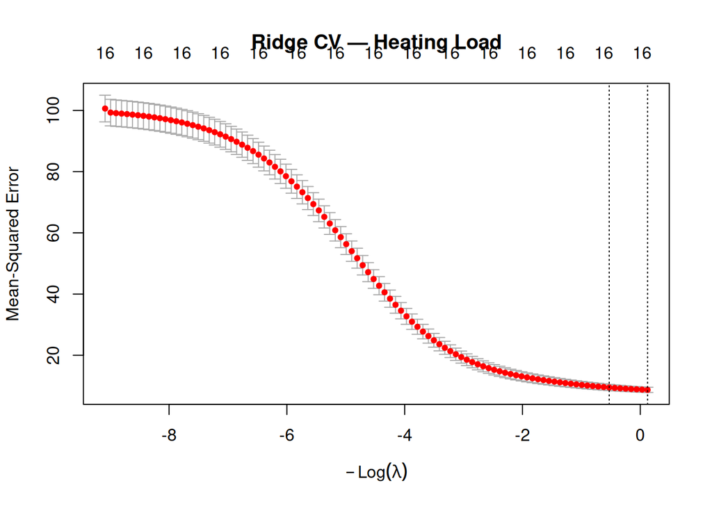

```r
plot(ridge_cv_HL, main = "Ridge CV — Heating Load")
```

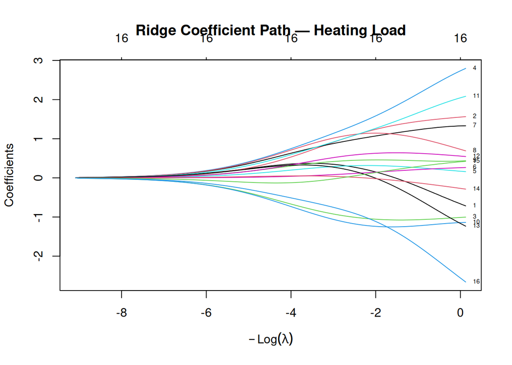

```r
ridge_full_HL <- glmnet(X_train, y_train_HL, alpha = 0)
plot(ridge_full_HL, xvar = "lambda",
     main = "Ridge Coefficient Path — Heating Load", label = TRUE)
```

```r
pred_ridge_HL <- predict(ridge_cv_HL, newx = X_test, s = "lambda.1se")
res_ridge_HL  <- eval_reg(y_test_HL, pred_ridge_HL, "Ridge Regression")
```

```
## Ridge Regression                          RMSE =  2.546  MAE =  1.835  R² = 0.9353
```

```r
results_HL <- rbind(results_HL,
  data.frame(Model = "Ridge Regression",
             RMSE = res_ridge_HL$rmse, MAE = res_ridge_HL$mae, R2 = res_ridge_HL$r2))
```

For Cooling Load, we have

```r
# Ridge
set.seed(42)
ridge_cv_CL   <- cv.glmnet(X_train, y_train_CL, alpha = 0, nfolds = 10)
pred_ridge_CL <- predict(ridge_cv_CL, newx = X_test, s = "lambda.1se")
res_ridge_CL  <- eval_reg(y_test_CL, pred_ridge_CL, "Ridge Regression")
```

```
## Ridge Regression                          RMSE =  2.888  MAE =  2.060  R² = 0.9026
```

```r
results_CL <- rbind(results_CL,
  data.frame(Model = "Ridge Regression",
             RMSE = res_ridge_CL$rmse, MAE = res_ridge_CL$mae, R2 = res_ridge_CL$r2))
```

The coefficient path shows that `OverallHeight`, `GlazingXHeight`, and the dominant negative-coefficient feature shrink last, confirming their genuine predictive signal. The cluster converging near zero at low −log(λ) corresponds to the highly collinear geometric features (`RelCompactness`, `RoofArea`, `SurfToVol`) whose large OLS coefficients were artefacts of multicollinearity. Ridge RMSE is 2.546 for HL and 2.888 for CL. For cooling load, Ridge is the best-performing linear model overall, suggesting that for CL the dominant source of error is collinearity rather than unmodelled nonlinearity.

## 4.7 Model 4 — Lasso Regression

```r
set.seed(42)
lasso_cv_HL <- cv.glmnet(X_train, y_train_HL, alpha = 1, nfolds = 10)
cat("=== LASSO REGRESSION — Heating Load ===\n")
```

```
## === LASSO REGRESSION — Heating Load ===
```

```r
cat(sprintf("Optimal lambda (1se): %.4f\n", lasso_cv_HL$lambda.1se))
```

```
## Optimal lambda (1se): 0.0209
```

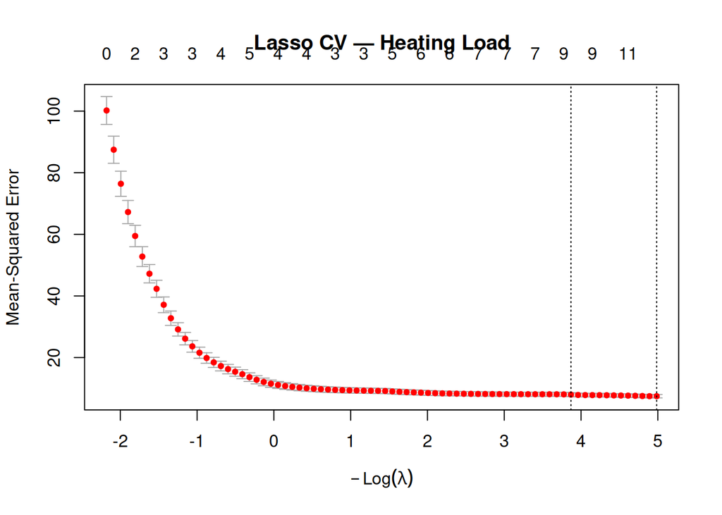

```r
plot(lasso_cv_HL, main = "Lasso CV — Heating Load")
```

```r
pred_lasso_HL <- predict(lasso_cv_HL, newx = X_test, s = "lambda.1se")
res_lasso_HL  <- eval_reg(y_test_HL, pred_lasso_HL, "Lasso Regression")
```

```
## Lasso Regression                          RMSE =  2.563  MAE =  1.808  R² = 0.9344
```

```r
lasso_coefs_HL <- coef(lasso_cv_HL, s = "lambda.1se")
selected_HL    <- rownames(lasso_coefs_HL)[lasso_coefs_HL[, 1] != 0]
cat("\nFeatures retained by Lasso:\n")
```

```
##
## Features retained by Lasso:
```

```r
print(selected_HL)
```

```
##  [1] "(Intercept)"     "WallArea"        "OverallHeight"   "GlazingAreaDist"
##  [5] "WallToRoofRatio" "SurfToVol"       "GlazingXHeight"  "WallXGlazing"
##  [9] "EnvelopeArea"    "WallPerHeight"
```

```r
cat("Features zeroed out:", length(base_features) + 1 - length(selected_HL), "\n")
```

```
## Features zeroed out: 7
```

```r
results_HL <- rbind(results_HL,
  data.frame(Model = "Lasso Regression",
             RMSE = res_lasso_HL$rmse, MAE = res_lasso_HL$mae, R2 = res_lasso_HL$r2))
```

For Cooling Load, we have

```r
# Lasso
set.seed(42)
lasso_cv_CL   <- cv.glmnet(X_train, y_train_CL, alpha = 1, nfolds = 10)
pred_lasso_CL <- predict(lasso_cv_CL, newx = X_test, s = "lambda.1se")
res_lasso_CL  <- eval_reg(y_test_CL, pred_lasso_CL, "Lasso Regression")
```

```
## Lasso Regression                          RMSE =  2.982  MAE =  2.150  R² = 0.8961
```

```r
lasso_coefs_CL <- coef(lasso_cv_CL, s = "lambda.1se")
selected_CL    <- rownames(lasso_coefs_CL)[lasso_coefs_CL[, 1] != 0]
cat("\nLasso features retained (Cooling Load):\n")
```

```
##
## Lasso features retained (Cooling Load):
```

```r
print(selected_CL)
```

```
##  [1] "(Intercept)"         "WallArea"            "OverallHeight"
##  [4] "GlazingAreaDist"     "WallToRoofRatio"     "GlazingXCompactness"
##  [7] "SurfToVol"           "GlazingXHeight"      "CompactnessSquared"
## [10] "WallPerHeight"
```

```r
results_CL <- rbind(results_CL,
  data.frame(Model = "Lasso Regression",
             RMSE = res_lasso_CL$rmse, MAE = res_lasso_CL$mae, R2 = res_lasso_CL$r2))
```

## 4.8 Model 5 — Elastic Net

```r
set.seed(42)
enet_cv_HL <- cv.glmnet(X_train, y_train_HL, alpha = 0.5, nfolds = 10)
cat("=== ELASTIC NET — Heating Load ===\n")
```

```
## === ELASTIC NET — Heating Load ===
```

```r
cat(sprintf("Optimal lambda (1se): %.4f\n", enet_cv_HL$lambda.1se))
```

```
## Optimal lambda (1se): 0.0034
```

```r
pred_enet_HL <- predict(enet_cv_HL, newx = X_test, s = "lambda.1se")
res_enet_HL  <- eval_reg(y_test_HL, pred_enet_HL, "Elastic Net (alpha=0.5)")
```

```
## Elastic Net (alpha=0.5)                   RMSE =  2.428  MAE =  1.760  R² = 0.9411
```

```r
enet_coefs_HL <- coef(enet_cv_HL, s = "lambda.1se")
selected_enet_HL <- rownames(enet_coefs_HL)[enet_coefs_HL[, 1] != 0]
cat("\nFeatures retained by Elastic Net:\n")
```

```
##
## Features retained by Elastic Net:
```

```r
print(selected_enet_HL)
```

```
##  [1] "(Intercept)"         "RelCompactness"      "WallArea"
##  [4] "RoofArea"            "OverallHeight"       "GlazingArea"
##  [7] "GlazingAreaDist"     "CompactnessXHeight"  "WallToRoofRatio"
## [10] "GlazingXCompactness" "SurfToVol"           "GlazingXHeight"
## [13] "WallXGlazing"        "CompactnessSquared"  "GlazingToWall"
## [16] "EnvelopeArea"        "WallPerHeight"
```

```r
results_HL <- rbind(results_HL,
  data.frame(Model = "Elastic Net",
             RMSE = res_enet_HL$rmse, MAE = res_enet_HL$mae, R2 = res_enet_HL$r2))
```

For Cooling Load, we have

```r
# Elastic Net
set.seed(42)
enet_cv_CL   <- cv.glmnet(X_train, y_train_CL, alpha = 0.5, nfolds = 10)
pred_enet_CL <- predict(enet_cv_CL, newx = X_test, s = "lambda.1se")
res_enet_CL  <- eval_reg(y_test_CL, pred_enet_CL, "Elastic Net (alpha=0.5)")
```

```
## Elastic Net (alpha=0.5)                   RMSE =  2.932  MAE =  2.181  R² = 0.8996
```

```r
results_CL   <- rbind(results_CL,
  data.frame(Model = "Elastic Net",
             RMSE = res_enet_CL$rmse, MAE = res_enet_CL$mae, R2 = res_enet_CL$r2))
```

Elastic Net (RMSE=2.428) marginally outperforms OLS with interactions (RMSE=2.470) despite retaining 16 of 16 features. The L1 penalty is small enough (λ=0.0034) that almost no zeroing occurs, and the benefit comes almost entirely from L2 shrinkage of the collinear geometric terms. This makes Elastic Net the best linear model for heating load. For cooling load, Ridge wins (RMSE=2.888) and Elastic Net is second (RMSE=2.932), suggesting the cooling load benefits more from uniform shrinkage than from sparsity.

```r
cat("=== RESIDUAL DIAGNOSTICS — OLS with Interactions ===\n")
```

```
## === RESIDUAL DIAGNOSTICS — OLS with Interactions ===
```

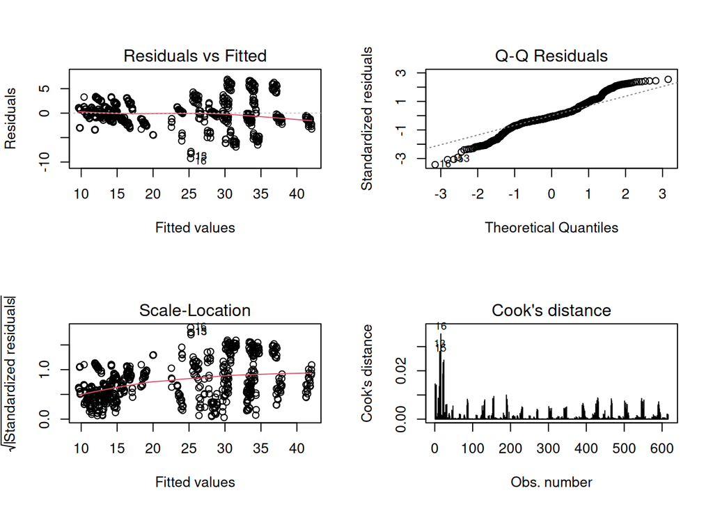

```r
par(mfrow = c(2, 2))
plot(lm_interact_HL, which = 1:4)
```

```r
par(mfrow = c(1, 1))

cat("\nBreusch-Pagan test for heteroscedasticity:\n")
```

```
##
## Breusch-Pagan test for heteroscedasticity:
```

```r
print(lmtest::bptest(lm_interact_HL))
```

```
##
##  studentized Breusch-Pagan test
##
## data:  lm_interact_HL
## BP = 268.87, df = 11, p-value < 2.2e-16
```

```r
cat("\nAnderson-Darling test on residuals:\n")
```

```
##
## Anderson-Darling test on residuals:
```

```r
print(nortest::ad.test(residuals(lm_interact_HL)))
```

```
##
##  Anderson-Darling normality test
##
## data:  residuals(lm_interact_HL)
## A = 8.1203, p-value < 2.2e-16
```

The Breusch-Pagan statistic (BP=268.9, df=11, p<2.2e-16) and Anderson-Darling statistic (A=8.12, p<2.2e-16) both reject their null hypotheses decisively. The interaction OLS model has severe heteroscedasticity and non-normal residuals — neither is surprising given the bimodal response distribution driven by `OverallHeight`. The residuals fan out differently for low-height and high-height buildings. This is not a modelling failure: it is a structural consequence of the two-cluster data-generating process that linear models cannot fully resolve. It directly motivates the domain-appropriate regression models in Part 3, which can partition the feature space rather than imposing a global linear relationship.

## 4.10 Linear Model Comparison

```r
cat("=== HEATING LOAD — Model Comparison ===\n")
```

```
## === HEATING LOAD — Model Comparison ===
```

```r
print(results_HL %>% arrange(RMSE))
```

```
##                   Model     RMSE      MAE        R2
## 1           Elastic Net 2.427844 1.759825 0.9411358
## 2 OLS with Interactions 2.469881 1.767705 0.9390797
## 3      Ridge Regression 2.545822 1.835267 0.9352759
## 4      Lasso Regression 2.563183 1.808429 0.9343901
## 5          Baseline OLS 2.839597 2.157793 0.9194763
```

```r
cat("\n=== COOLING LOAD — Model Comparison ===\n")
```

```
##
## === COOLING LOAD — Model Comparison ===
```

```r
print(results_CL %>% arrange(RMSE))
```

```
##                   Model     RMSE      MAE        R2
## 1      Ridge Regression 2.887706 2.060452 0.9025849
## 2           Elastic Net 2.931683 2.180751 0.8995952
## 3 OLS with Interactions 2.978057 2.057406 0.8963936
## 4      Lasso Regression 2.982344 2.150472 0.8960951
## 5          Baseline OLS 3.161479 2.305773 0.8832381
```

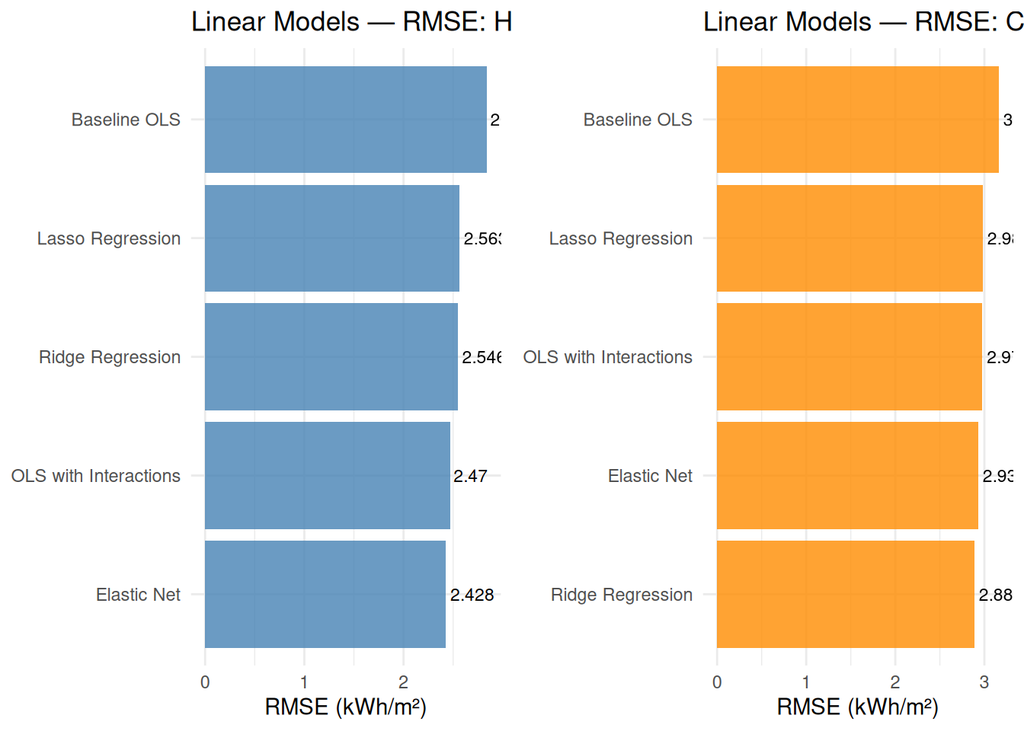

```r
p_HL <- ggplot(results_HL %>% arrange(RMSE),
               aes(x = reorder(Model, RMSE), y = RMSE)) +
  geom_col(fill = "steelblue", alpha = 0.8) +
  geom_text(aes(label = round(RMSE, 3)), hjust = -0.1, size = 3) +
  coord_flip() +
  labs(title = "Linear Models — RMSE: Heating Load",
       x = NULL, y = "RMSE (kWh/m²)") +
  theme_minimal()

p_CL <- ggplot(results_CL %>% arrange(RMSE),
               aes(x = reorder(Model, RMSE), y = RMSE)) +
  geom_col(fill = "darkorange", alpha = 0.8) +
  geom_text(aes(label = round(RMSE, 3)), hjust = -0.1, size = 3) +
  coord_flip() +
  labs(title = "Linear Models — RMSE: Cooling Load",
       x = NULL, y = "RMSE (kWh/m²)") +
  theme_minimal()

grid.arrange(p_HL, p_CL, ncol = 2)
```

The RMSE reduction from Baseline OLS to the best model is 0.412 kWh/m² for heating load (14.5% improvement) and 0.273 kWh/m² for cooling load (8.6% improvement). The smaller gain for cooling load reflects a flatter response surface that leaves less room for feature engineering to help. **The linear baselines to carry forward into Part 3 are Elastic Net for heating load (RMSE=2.428, R²=0.941) and Ridge for cooling load (RMSE=2.888, R²=0.903).**

# 5 Part 3 — Domain-Appropriate Regression Models

## 5.1 Why These Models?

The models in a conventional nonlinear analysis include Random Forest, XGBoost, SVM, Neural Network which are general-purpose algorithms. They work on almost any tabular dataset without needing to know what the data represents. That is both their strength and their limitation.

ENB2012 was generated by EnergyPlus, a thermodynamic simulator, using the physics of heat transfer through building envelopes. The relationship between building geometry and energy load is not arbitrary as it follows physical laws. This creates two opportunities: (1) models suited to small, structured, simulation-generated datasets can extract more information from 768 rows than a general-purpose learner, and (2) models can be validated not just by test error but by checking whether predictions respect physical logic.

**The linear baseline established in Part 2 was Elastic Net (HL RMSE=2.428) and Ridge (CL RMSE=2.888). This is the target these models are measured against.**

Three models are introduced:

- **GPR with an RBF kernel** — a Bayesian model that treats the dataset as a probability distribution over functions; naturally suited to surrogate modelling of simulation outputs.
- **GPR with a Laplace (Matérn ½) kernel** — a variant assuming the geometry-to-load relationship is less smooth than the RBF kernel assumes, allowing systematic comparison of kernel choices. Note: `kernlab` does not implement Matérn 5/2 natively; `laplacedot` (Ornstein-Uhlenbeck / Matérn ½) is the closest available kernel and is used here with that label.
- **LightGBM** — a modern leaf-wise gradient boosting algorithm that handles the discrete, categorical-like structure of ENB2012 more efficiently than depth-wise methods.

## 5.2 Data Setup

```r
# Reload the post-EDA dataset (features already engineered above;
# reproduced here for standalone section clarity)
df_gpr <- df

df_gpr <- df_gpr %>%
  mutate(
    CompactnessXHeight  = RelCompactness * OverallHeight,
    WallToRoofRatio     = WallArea / RoofArea,
    GlazingXCompactness = GlazingArea * RelCompactness,
    SurfToVol           = SurfaceArea / (WallArea + RoofArea),
    GlazingXHeight      = GlazingArea * OverallHeight,
    WallXGlazing        = WallArea * GlazingArea,
    CompactnessSquared  = RelCompactness^2,
    HeightSquared       = OverallHeight^2,
    GlazingToWall       = GlazingArea / (WallArea + 1),
    EnvelopeArea        = WallArea + RoofArea,
    WallPerHeight       = WallArea / (OverallHeight + 1),
    group_key           = paste(RelCompactness, WallArea, RoofArea,
                                OverallHeight, GlazingArea, GlazingAreaDist, sep = "_")
  )

set.seed(42)
unique_groups_gpr  <- unique(df_gpr$group_key)
n_train_gpr        <- round(0.80 * length(unique_groups_gpr))
train_groups_gpr   <- sample(unique_groups_gpr, n_train_gpr)

df_train_gpr <- df_gpr %>% filter( group_key %in% train_groups_gpr)
df_test_gpr  <- df_gpr %>% filter(!group_key %in% train_groups_gpr)

cat("Training rows:", nrow(df_train_gpr), "\n")
```

```
## Training rows: 616
```

```r
cat("Test rows    :", nrow(df_test_gpr),  "\n")
```

```
## Test rows    : 152
```

```r
cat("Group overlap:", length(intersect(df_train_gpr$group_key,
                                       df_test_gpr$group_key)), "<- zero leakage\n")
```

```
## Group overlap: 0 <- zero leakage
```

## 5.3 Feature Set and Scaling

```r
features <- c(
  "RelCompactness", "WallArea", "RoofArea",
  "OverallHeight", "GlazingArea", "GlazingAreaDist",
  "CompactnessXHeight", "WallToRoofRatio", "GlazingXCompactness",
  "SurfToVol", "GlazingXHeight", "WallXGlazing",
  "CompactnessSquared", "GlazingToWall", "EnvelopeArea", "WallPerHeight"
)

preproc_gpr <- caret::preProcess(df_train_gpr[, features],
                                  method = c("center", "scale"))
df_train_gpr[, features] <- predict(preproc_gpr, df_train_gpr[, features])
df_test_gpr[, features]  <- predict(preproc_gpr, df_test_gpr[, features])

cat("Scaling complete. Fitted on training set only.\n")
```

```
## Scaling complete. Fitted on training set only.
```

## 5.4 Evaluation Helper

```r
eval_reg_dom <- function(actual, predicted, model_name) {
  rmse <- sqrt(mean((actual - predicted)^2))
  mae  <- mean(abs(actual - predicted))
  r2   <- 1 - sum((actual - predicted)^2) / sum((actual - mean(actual))^2)
  cat(sprintf("%-35s  RMSE=%.4f  MAE=%.4f  R²=%.4f\n", model_name, rmse, mae, r2))
  data.frame(Model = model_name, RMSE = rmse, MAE = mae, R2 = r2)
}

# Seed results tables with the linear baselines from Part 2 for direct comparison
results_y1 <- data.frame(Model = "Linear Baseline (Elastic Net)",
                          RMSE  = 2.428, MAE = 1.760, R2 = 0.9411)
results_y2 <- data.frame(Model = "Linear Baseline (Ridge)",
                          RMSE  = 2.888, MAE = 2.060, R2 = 0.9026)
```

## 5.5 Model A — GPR with RBF Kernel

The RBF kernel assumes the function being learned is **infinitely smooth**: buildings that differ slightly in geometry will differ only slightly in energy load, with no abrupt jumps anywhere. In mathematical terms:

k(x, x’) = σ² × exp(−||x − x’||² / 2ℓ²)

```r
set.seed(42)
gpr_rbf_y1 <- gausspr(
  x      = as.matrix(df_train_gpr[, features]),
  y      = df_train_gpr$HeatingLoad,
  kernel = "rbfdot",
  kpar   = "automatic",
  var    = 0.01
)
```

```
## Using automatic sigma estimation (sigest) for RBF or laplace kernel
```

```r
cat("=== GPR (RBF) — Heating Load ===\n")
```

```
## === GPR (RBF) — Heating Load ===
```

```r
print(gpr_rbf_y1)
```

```
## Gaussian Processes object of class "gausspr"
## Problem type: regression
##
## Gaussian Radial Basis kernel function.
##  Hyperparameter : sigma =  0.0819666141081652
##
## Number of training instances learned : 616
## Train error : 0.002812208
```

```r
pred_gpr_rbf_y1 <- predict(gpr_rbf_y1,
                             newdata = as.matrix(df_test_gpr[, features]))
results_y1 <- rbind(results_y1,
  eval_reg_dom(df_test_gpr$HeatingLoad, pred_gpr_rbf_y1, "GPR (RBF)"))
```

```
## GPR (RBF)                            RMSE=1.1234  MAE=0.8147  R²=0.9874
```

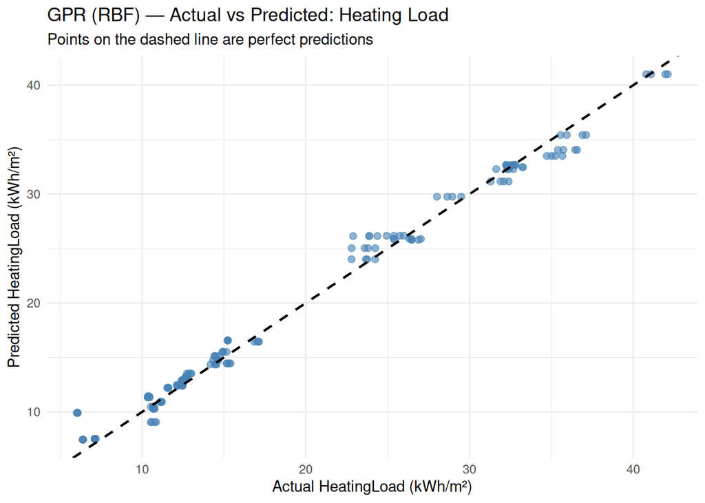

```r
gpr_rbf_y1_df <- data.frame(
  Actual    = df_test_gpr$HeatingLoad,
  Predicted = as.vector(pred_gpr_rbf_y1),
  Residual  = df_test_gpr$HeatingLoad - as.vector(pred_gpr_rbf_y1)
)
p_gpr_rbf_y1 <- ggplot(gpr_rbf_y1_df, aes(x = Actual, y = Predicted)) +
  geom_point(alpha = 0.6, colour = "steelblue", size = 2) +
  geom_abline(slope = 1, intercept = 0, colour = "black",
              linetype = "dashed", linewidth = 0.8) +
  labs(title    = "GPR (RBF) — Actual vs Predicted: Heating Load",
       subtitle = "Points on the dashed line are perfect predictions",
       x = "Actual HeatingLoad (kWh/m²)", y = "Predicted HeatingLoad (kWh/m²)") +
  theme_minimal()
print(p_gpr_rbf_y1)
```

```r
set.seed(42)
gpr_rbf_y2 <- gausspr(
  x      = as.matrix(df_train_gpr[, features]),
  y      = df_train_gpr$CoolingLoad,
  kernel = "rbfdot",
  kpar   = "automatic",
  var    = 0.01
)
```

```
## Using automatic sigma estimation (sigest) for RBF or laplace kernel
```

```r
pred_gpr_rbf_y2 <- predict(gpr_rbf_y2,
                             newdata = as.matrix(df_test_gpr[, features]))
results_y2 <- rbind(results_y2,
  eval_reg_dom(df_test_gpr$CoolingLoad, pred_gpr_rbf_y2, "GPR (RBF)"))
```

```
## GPR (RBF)                            RMSE=2.0260  MAE=1.5027  R²=0.9520
```

## 5.6 Model B — GPR with Laplace (Matérn ½) Kernel

The Laplace kernel (Ornstein-Uhlenbeck / Matérn ν=1/2) assumes the underlying function is continuous but not differentiable. This allows for sharper transitions in the geometry-to-load relationship than the RBF kernel. The data’s features include discrete variables (`GlazingArea` takes only four values, `OverallHeight` only two), and the EnergyPlus outputs jump discontinuously between these levels rather than varying smoothly. The less-smooth Laplace kernel may handle these step-like patterns better than the infinitely smooth RBF kernel.

Comparing the two models’ RMSE and residual patterns directly tells us which smoothness assumption better matches the actual structure of the data.

```r
set.seed(42)
gpr_mat_y1 <- gausspr(
  x      = as.matrix(df_train_gpr[, features]),
  y      = df_train_gpr$HeatingLoad,
  kernel = "laplacedot",
  kpar   = "automatic",
  var    = 0.01
)
```

```
## Using automatic sigma estimation (sigest) for RBF or laplace kernel
```

```r
cat("=== GPR (Laplace / Matern 1/2) — Heating Load ===\n")
```

```
## === GPR (Laplace / Matern 1/2) — Heating Load ===
```

```r
print(gpr_mat_y1)
```

```
## Gaussian Processes object of class "gausspr"
## Problem type: regression
##
## Laplace kernel function.
##  Hyperparameter : sigma =  0.0819666141081652
##
## Number of training instances learned : 616
## Train error : 0.001370566
```

```r
pred_gpr_mat_y1 <- predict(gpr_mat_y1,
                             newdata = as.matrix(df_test_gpr[, features]))
results_y1 <- rbind(results_y1,
  eval_reg_dom(df_test_gpr$HeatingLoad, pred_gpr_mat_y1, "GPR (Laplace)"))
```

```
## GPR (Laplace)                        RMSE=2.0339  MAE=1.3849  R²=0.9587
```

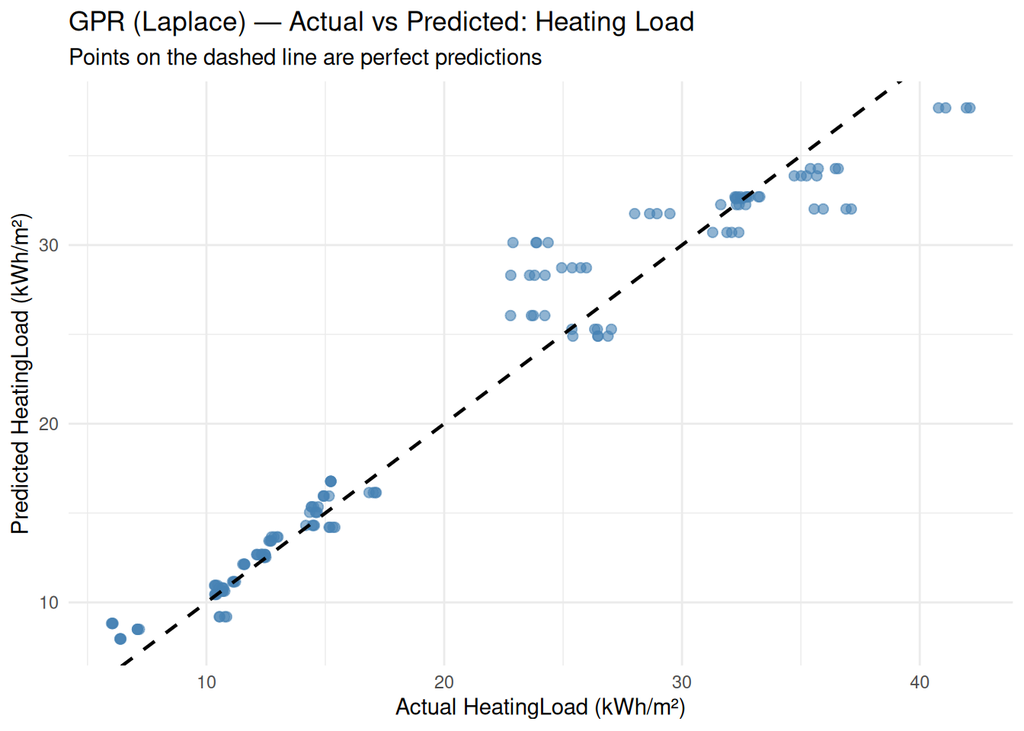

```r
gpr_mat_y1_df <- data.frame(
  Actual    = df_test_gpr$HeatingLoad,
  Predicted = as.vector(pred_gpr_mat_y1),
  Residual  = df_test_gpr$HeatingLoad - as.vector(pred_gpr_mat_y1)
)
p_gpr_mat_y1 <- ggplot(gpr_mat_y1_df, aes(x = Actual, y = Predicted)) +
  geom_point(alpha = 0.6, colour = "steelblue", size = 2) +
  geom_abline(slope = 1, intercept = 0, colour = "black",
              linetype = "dashed", linewidth = 0.8) +
  labs(title    = "GPR (Laplace) — Actual vs Predicted: Heating Load",
       subtitle = "Points on the dashed line are perfect predictions",
       x = "Actual HeatingLoad (kWh/m²)", y = "Predicted HeatingLoad (kWh/m²)") +
  theme_minimal()
print(p_gpr_mat_y1)
```

```r
set.seed(42)
gpr_mat_y2 <- gausspr(
  x      = as.matrix(df_train_gpr[, features]),
  y      = df_train_gpr$CoolingLoad,
  kernel = "laplacedot",
  kpar   = "automatic",
  var    = 0.01
)
```

```
## Using automatic sigma estimation (sigest) for RBF or laplace kernel
```

```r
pred_gpr_mat_y2 <- predict(gpr_mat_y2,
                             newdata = as.matrix(df_test_gpr[, features]))
results_y2 <- rbind(results_y2,
  eval_reg_dom(df_test_gpr$CoolingLoad, pred_gpr_mat_y2, "GPR (Laplace)"))
```

```
## GPR (Laplace)                        RMSE=2.5030  MAE=1.7113  R²=0.9268
```

## 5.7 GPR Kernel Comparison

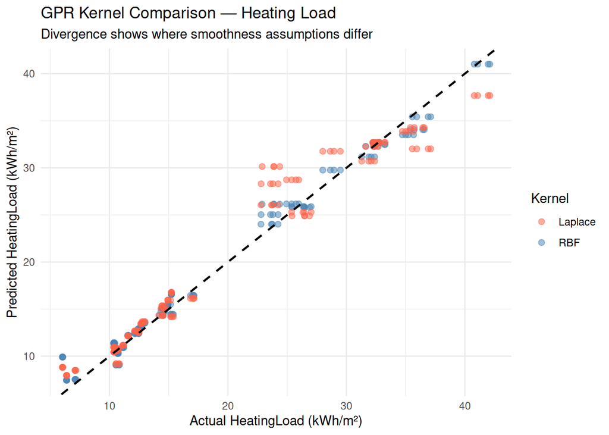

```r
kernel_compare_y1 <- bind_rows(
  data.frame(Actual    = df_test_gpr$HeatingLoad,
             Predicted = as.vector(pred_gpr_rbf_y1), Kernel = "RBF"),
  data.frame(Actual    = df_test_gpr$HeatingLoad,
             Predicted = as.vector(pred_gpr_mat_y1), Kernel = "Laplace")
)
p_kernel_y1 <- ggplot(kernel_compare_y1, aes(x = Actual, y = Predicted,
                                               colour = Kernel)) +
  geom_point(alpha = 0.5, size = 2) +
  geom_abline(slope = 1, intercept = 0, colour = "black",
              linetype = "dashed", linewidth = 0.8) +
  scale_colour_manual(values = c("RBF" = "steelblue", "Laplace" = "tomato")) +
  labs(title    = "GPR Kernel Comparison — Heating Load",
       subtitle = "Divergence shows where smoothness assumptions differ",
       x = "Actual HeatingLoad (kWh/m²)", y = "Predicted HeatingLoad (kWh/m²)") +
  theme_minimal()
print(p_kernel_y1)
```

## 5.8 Model C — LightGBM

LightGBM grows trees **leaf-wise**: at each step it finds the single leaf whose split would most reduce the loss and expands only that leaf. This produces deeper, more asymmetric trees that fit complex patterns more efficiently than depth-wise methods. For the data specifically, LightGBM’s histogram-based split-finding algorithm naturally groups the few discrete feature values into bins before finding splits, aligning well with the dataset’s structure.

```r
X_train_lgbm <- as.matrix(df_train_gpr[, features])
X_test_lgbm  <- as.matrix(df_test_gpr[,  features])

dtrain_y1 <- lgb.Dataset(data  = X_train_lgbm,
                           label = df_train_gpr$HeatingLoad)

lgbm_grid <- expand.grid(
  num_leaves    = c(15, 31),
  learning_rate = c(0.05, 0.10)
)

lgbm_tune_y1 <- purrr::pmap_dfr(lgbm_grid, function(num_leaves, learning_rate) {
  params <- list(
    objective = "regression", metric = "rmse",
    num_leaves = num_leaves, learning_rate = learning_rate,
    min_data_in_leaf = 5, feature_fraction = 0.8,
    bagging_fraction = 0.8, bagging_freq = 5, verbose = -1
  )
  set.seed(42)
  cv_result <- lgb.cv(params = params, data = dtrain_y1, nfold = 5,
                       nrounds = 500, early_stopping_rounds = 30, verbose = -1)
  best_rmse <- min(unlist(cv_result$record_evals$valid$rmse$eval))
  best_iter <- which.min(unlist(cv_result$record_evals$valid$rmse$eval))
  data.frame(num_leaves = num_leaves, learning_rate = learning_rate,
             best_rmse_cv = round(best_rmse, 5), best_nrounds = best_iter)
})

cat("=== LightGBM Tuning Grid — Heating Load ===\n")
```

```
## === LightGBM Tuning Grid — Heating Load ===
```

```r
print(lgbm_tune_y1)
```

```
##   num_leaves learning_rate best_rmse_cv best_nrounds
## 1         15          0.05      0.49455          195
## 2         31          0.05      0.50022          195
## 3         15          0.10      0.49246          145
## 4         31          0.10      0.51168          134
```

```r
best_row_y1 <- lgbm_tune_y1[which.min(lgbm_tune_y1$best_rmse_cv), ]
cat("\nSelected configuration:\n")
```

```
##
## Selected configuration:
```

```r
print(best_row_y1)
```

```
##   num_leaves learning_rate best_rmse_cv best_nrounds
## 3         15           0.1      0.49246          145
```

```r
best_params_y1 <- list(
  objective = "regression", metric = "rmse",
  num_leaves = best_row_y1$num_leaves, learning_rate = best_row_y1$learning_rate,
  min_data_in_leaf = 5, feature_fraction = 0.8,
  bagging_fraction = 0.8, bagging_freq = 5, verbose = -1
)

set.seed(42)
lgbm_y1 <- lgb.train(params  = best_params_y1,
                       data    = dtrain_y1,
                       nrounds = best_row_y1$best_nrounds)

pred_lgbm_y1 <- predict(lgbm_y1, X_test_lgbm)
results_y1 <- rbind(results_y1,
  eval_reg_dom(df_test_gpr$HeatingLoad, pred_lgbm_y1, "LightGBM"))
```

```
## LightGBM                             RMSE=0.5191  MAE=0.3824  R²=0.9973
```

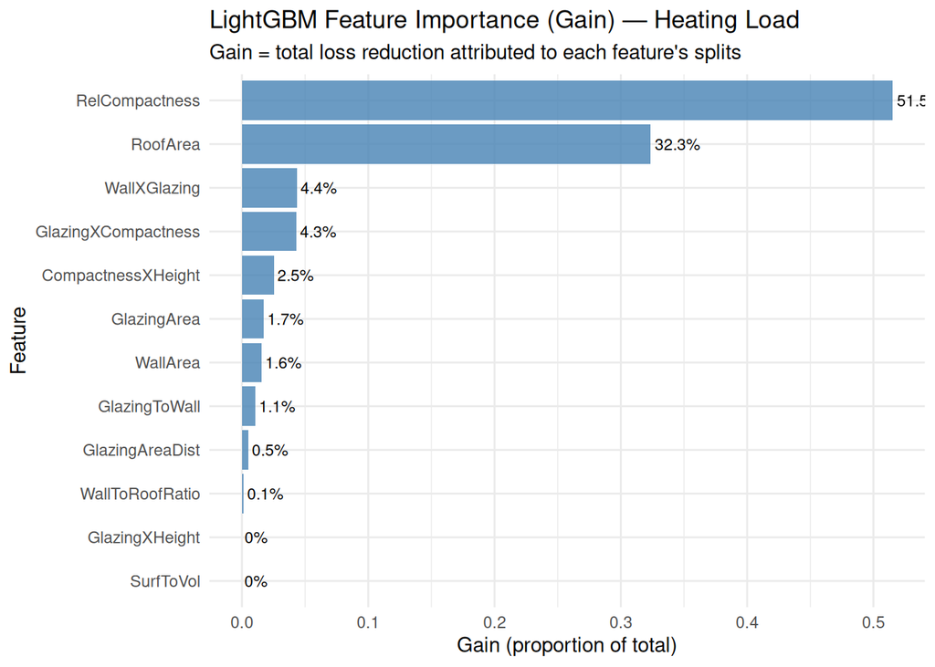

```r
lgbm_imp_y1 <- lgb.importance(lgbm_y1, percentage = TRUE)
p_lgbm_imp_y1 <- lgbm_imp_y1 %>% head(12) %>%
  ggplot(aes(x = reorder(Feature, Gain), y = Gain)) +
  geom_col(fill = "steelblue", alpha = 0.8) +
  geom_text(aes(label = paste0(round(Gain * 100, 1), "%")),
            hjust = -0.1, size = 3) +
  coord_flip() +
  labs(title    = "LightGBM Feature Importance (Gain) — Heating Load",
       subtitle = "Gain = total loss reduction attributed to each feature's splits",
       x = "Feature", y = "Gain (proportion of total)") +
  theme_minimal()
print(p_lgbm_imp_y1)
```

```r
dtrain_y2 <- lgb.Dataset(data  = X_train_lgbm,
                           label = df_train_gpr$CoolingLoad)

lgbm_tune_y2 <- purrr::pmap_dfr(lgbm_grid, function(num_leaves, learning_rate) {
  params <- list(
    objective = "regression", metric = "rmse",
    num_leaves = num_leaves, learning_rate = learning_rate,
    min_data_in_leaf = 5, feature_fraction = 0.8,
    bagging_fraction = 0.8, bagging_freq = 5, verbose = -1
  )
  set.seed(42)
  cv_result <- lgb.cv(params = params, data = dtrain_y2, nfold = 5,
                       nrounds = 500, early_stopping_rounds = 30, verbose = -1)
  best_rmse <- min(unlist(cv_result$record_evals$valid$rmse$eval))
  best_iter <- which.min(unlist(cv_result$record_evals$valid$rmse$eval))
  data.frame(num_leaves = num_leaves, learning_rate = learning_rate,
             best_rmse_cv = round(best_rmse, 5), best_nrounds = best_iter)
})

best_row_y2 <- lgbm_tune_y2[which.min(lgbm_tune_y2$best_rmse_cv), ]
best_params_y2 <- list(
  objective = "regression", metric = "rmse",
  num_leaves = best_row_y2$num_leaves, learning_rate = best_row_y2$learning_rate,
  min_data_in_leaf = 5, feature_fraction = 0.8,
  bagging_fraction = 0.8, bagging_freq = 5, verbose = -1
)
set.seed(42)
lgbm_y2 <- lgb.train(params = best_params_y2, data = dtrain_y2,
                       nrounds = best_row_y2$best_nrounds)
pred_lgbm_y2 <- predict(lgbm_y2, X_test_lgbm)
results_y2 <- rbind(results_y2,
  eval_reg_dom(df_test_gpr$CoolingLoad, pred_lgbm_y2, "LightGBM"))
```

```
## LightGBM                             RMSE=1.6399  MAE=1.1318  R²=0.9686
```

## 5.9 Model D — MARS (Multivariate Adaptive Regression Splines)

The EDA established two facts that motivate MARS specifically: the response is bimodal at `OverallHeight = 7m`, and the `OverallHeight × GlazingArea` interaction plot shows a crossing pattern. Global linear terms average across both of these as they impose a single slope for `OverallHeight` across both height clusters and a single interaction coefficient that cannot shift at the crossing point.

MARS addresses this by searching the training data for **knots** which are breakpoints where the feature-response relationship changes direction. It then fits piecewise-linear hinge functions of the form `max(0, x − t)` on either side. The model is built by a forward pass (adding hinges) followed by a backward pruning pass using GCV. `degree = 2` allows pairwise interaction hinges, which is physically motivated by the confirmed `OverallHeight × GlazingArea` crossing. The result is an explicit, printable formula. This is the only model in this analysis that a building engineer can audit without specialist software.

```r
library(earth)

set.seed(42)
mars_y1 <- earth(
  x       = as.matrix(df_train_gpr[, features]),
  y       = df_train_gpr$HeatingLoad,
  degree  = 2,
  nk      = 50,
  thresh  = 0.001,
  pmethod = "backward",
  nfold   = 10,
  keepxy  = TRUE
)

cat("=== MARS — Heating Load ===\n")
```

```
## === MARS — Heating Load ===
```

```r
print(summary(mars_y1, digits = 4))
```

```
## Call: earth(x=as.matrix(df_train_gpr[,features]), y=df_train_gpr$HeatingLoad,
##             pmethod="backward", keepxy=TRUE, degree=2, nfold=10, nk=50,
##             thresh=0.001)
##
##                                                          coefficients
## (Intercept)                                                    46.680
## h(0.592802-CompactnessXHeight)                                -12.837
## h(CompactnessXHeight-0.592802)                                -79.609
## h(0.975325-WallToRoofRatio)                                    -9.550
## h(WallToRoofRatio-0.975325)                                   -13.100
## h(-1.10704-GlazingXCompactness)                               -10.051
## h(GlazingXCompactness- -1.10704)                                2.596
## h(WallXGlazing- -0.984117)                                      0.433
## h(CompactnessXHeight-0.592802) * h(SurfToVol- -0.453422)      190.403
## h(CompactnessXHeight-0.592802) * h(-0.453422-SurfToVol)        90.908
## h(0.975325-WallToRoofRatio) * h(1.37252-WallXGlazing)           0.791
## h(0.975325-WallToRoofRatio) * h(EnvelopeArea-0.801792)          4.381
## h(0.975325-WallToRoofRatio) * h(WallPerHeight-1.3992)         -10.813
##
## Selected 13 of 17 terms, and 7 of 16 predictors
## Termination condition: RSq changed by less than 0.001 at 17 terms
## Importance: CompactnessXHeight, GlazingXCompactness, WallToRoofRatio, ...
## Number of terms at each degree of interaction: 1 7 5
## GCV 0.3357  RSS 186.5  GRSq 0.9967  RSq 0.997  CVRSq 0.997
##
## Note: the cross-validation sd's below are standard deviations across folds
##
## Cross validation:   nterms 14.80 sd 1.40    nvars 6.30 sd 0.48
##
##      CVRSq    sd     MaxErr   sd
##      0.997 0.001       3.01 1.45
```

```r
pred_mars_y1 <- predict(mars_y1,
                         newdata = as.matrix(df_test_gpr[, features]))
results_y1 <- rbind(results_y1,
  eval_reg_dom(df_test_gpr$HeatingLoad, pred_mars_y1, "MARS"))
```

```
## MARS                                 RMSE=0.6378  MAE=0.4939  R²=0.9959
```

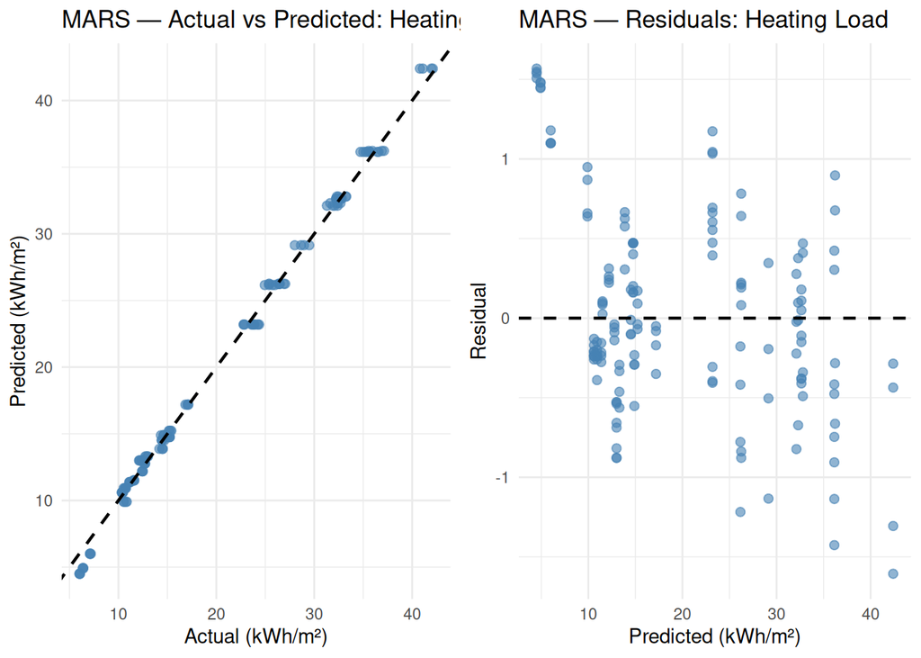

```r
mars_y1_df <- data.frame(
  Actual    = df_test_gpr$HeatingLoad,
  Predicted = as.vector(pred_mars_y1),
  Residual  = df_test_gpr$HeatingLoad - as.vector(pred_mars_y1)
)

p1 <- ggplot(mars_y1_df, aes(x = Actual, y = Predicted)) +
  geom_point(alpha = 0.6, colour = "steelblue", size = 2) +
  geom_abline(slope = 1, intercept = 0, linetype = "dashed",
              colour = "black", linewidth = 0.8) +
  labs(title = "MARS — Actual vs Predicted: Heating Load",
       x = "Actual (kWh/m²)", y = "Predicted (kWh/m²)") +
  theme_minimal()

p2 <- ggplot(mars_y1_df, aes(x = Predicted, y = Residual)) +
  geom_point(alpha = 0.6, colour = "steelblue", size = 2) +
  geom_hline(yintercept = 0, linetype = "dashed",
             colour = "black", linewidth = 0.8) +
  labs(title = "MARS — Residuals: Heating Load",
       x = "Predicted (kWh/m²)", y = "Residual") +
  theme_minimal()

grid.arrange(p1, p2, ncol = 2)
```

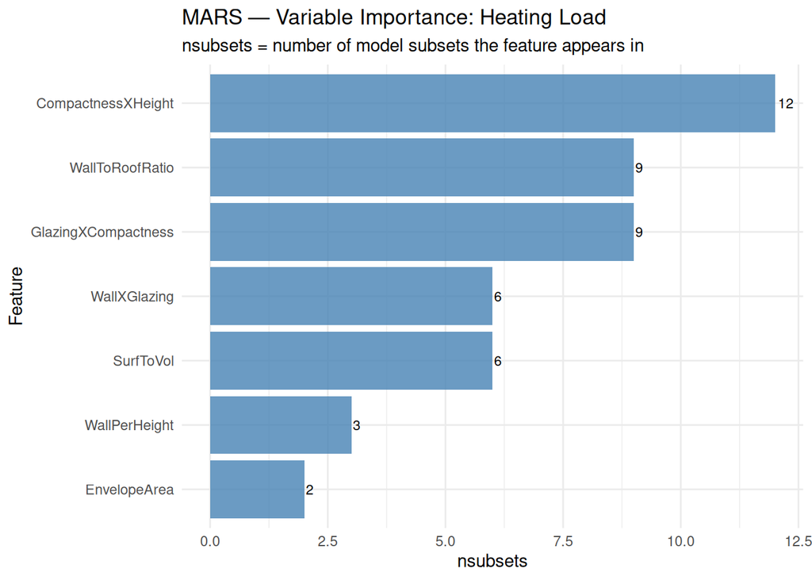

```r
# Variable importance: nsubsets = how consistently each feature was selected
mars_imp_y1 <- earth::evimp(mars_y1)
data.frame(
  Feature   = rownames(mars_imp_y1),
  nsubsets  = as.numeric(mars_imp_y1[, "nsubsets"]),
  gcv       = as.numeric(mars_imp_y1[, "gcv"])
) %>%
  arrange(desc(nsubsets)) %>% head(12) %>%
  ggplot(aes(x = reorder(Feature, nsubsets), y = nsubsets)) +
  geom_col(fill = "steelblue", alpha = 0.8) +
  geom_text(aes(label = nsubsets), hjust = -0.2, size = 3) +
  coord_flip() +
  labs(title    = "MARS — Variable Importance: Heating Load",
       subtitle = "nsubsets = number of model subsets the feature appears in",
       x = "Feature", y = "nsubsets") +
  theme_minimal()
```

```r
set.seed(42)
mars_y2 <- earth(
  x = as.matrix(df_train_gpr[, features]), y = df_train_gpr$CoolingLoad,
  degree = 2, nk = 50, thresh = 0.001, pmethod = "backward",
  nfold = 10, keepxy = TRUE
)
cat("=== MARS — Cooling Load ===\n")
```

```
## === MARS — Cooling Load ===
```

```r
cat(sprintf("Terms retained after pruning: %d\n",
            length(mars_y2$selected.terms)))
```

```
## Terms retained after pruning: 13
```

```r
pred_mars_y2 <- predict(mars_y2,
                         newdata = as.matrix(df_test_gpr[, features]))
results_y2 <- rbind(results_y2,
  eval_reg_dom(df_test_gpr$CoolingLoad, pred_mars_y2, "MARS"))
```

```
## MARS                                 RMSE=1.5386  MAE=1.0508  R²=0.9723
```